# Regresión 1

Paul Esker

## Antecedentes

En esta parte del taller vamos a empezar con los primeros modelos con base en regresión. En esta situación el objetivo es relacionar una variable dependiente con una otra independiente. Esto significa que tenemos la idea que la variable independiente explique algo sobre la variable dependiente. Por ejemplo, uno puede pensar en una relación entre la altura de una planta con algún indíce de crecimiento de hojas.

La forma para considerar el modelo es simplemiente
$$Y = f(X) + e$$

En donde:

- Y = variable dependiente,
- f(X) = una función que relaciona la variable independiente con la dependiente,
- e = error, la forma que depende del tipo de supuesto (por ejemplo, para una regresión lineal el error se está asumido a ser normal).

Para el primer ejemplo de regresión lineal lo que se pretende hacer es el análisis “más” completo lo cual significa una revisión de los supuestos y las predicciones. En algunos ejemplos que vienen se van a ejecutar los análisis de una manera un poco más sencilla para poder enfocarse más en la razón de utilizar aquella herramienta.

```r
library(tidyverse)
library(Hmisc)
```

```r
library(corrplot)
library(readr)
library(HH)
library(car)
```

## Datos

En este ejemplo vamos a introducir los datos “a mano” como los ejemplos anteriores. Los datos pertanecen a un estudio de maní en donde se trató de relacionar el porcentaje de limpieza de granos con la concentración de alfatoxina en *ppb* (ug por kg).

Las dos variables son:

- limpia = porcentaje de granos limpios de maní
- alfatoxina = concentración de alfatoxina

|  | limpia | aflatoxina |
| --- | --- | --- |
| 1 | 99.97 | 3.0 |
| 2 | 99.94 | 18.8 |
| 3 | 99.86 | 46.8 |
| 4 | 99.98 | 4.7 |
| 5 | 99.93 | 18.9 |
| 6 | 99.81 | 46.8 |

## Análisis exploratorio y gráfico

```r
mean(aflatoxina)
```

```
## [1] 36.60294
```

```r
sd(aflatoxina)
```

```
## [1] 29.3194
```

```r
sd(aflatoxina)/mean(aflatoxina)*100
```

```
## [1] 80.1012
```

```r
mean(limpia)
```

```
## [1] 99.89647
```

```r
sd(limpia)
```

```
## [1] 0.09351332
```

```r
sd(limpia)/mean(limpia)*100
```

```
## [1] 0.09361024
```

```r
cor(limpia, aflatoxina)
```

```
## [1] -0.9069581
```

```r
rcorr(limpia, aflatoxina)
```

```
##       x     y
## x  1.00 -0.91
## y -0.91  1.00
##
## n= 34
##
##
## P
##   x  y
## x     0
## y  0
```

## Regresión lineal

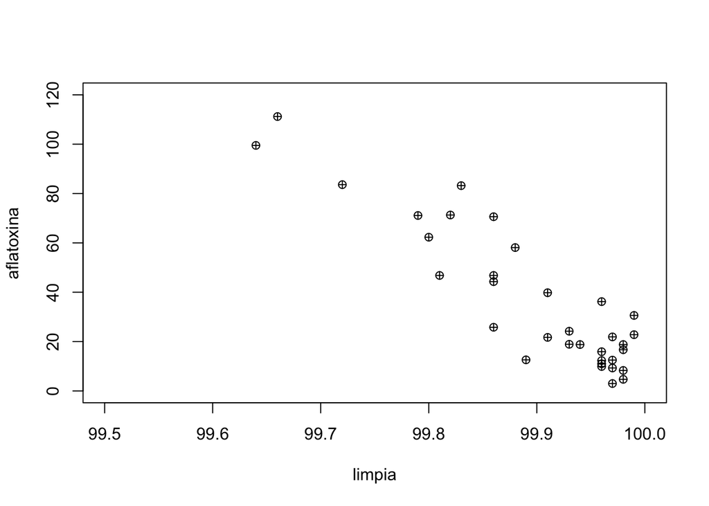

```r
# Vamos a visualizar la relación entre las dos variables
with(mani, plot(x=limpia, y=aflatoxina, xlim=c(99.5,100), ylim=c(0,120), pch=10))
```

```r
# Ejecutar la función lm() para realizar la regresión lineal

regresion_lineal <- with(mani, lm(aflatoxina~limpia)) #Formato, Y <- X
anova(regresion_lineal) #Tabla de ANDEVA tradicional para ver lo del significado
```

|  | Df | Sum Sq | Mean Sq | F value | Pr(>F) |
| --- | --- | --- | --- | --- | --- |
| limpia | 1 | 23334.493 | 23334.4931 | 148.3558 | 1.47907e-13 |
| Residuals | 32 | 5033.197 | 157.2874 | NA | NA |

```r
summary(regresion_lineal) #Esta versión proporciona más detalles, ver el documento para los componentes a interpretar
```

```
##
## Call:
## lm(formula = aflatoxina ~ limpia)
##
## Residuals:
##     Min      1Q  Median      3Q     Max
## -25.843  -7.997  -2.771   6.835  27.695
##
## Coefficients:
##             Estimate Std. Error t value Pr(>|t|)
## (Intercept) 28443.18    2332.21   12.20 1.43e-13 ***
## limpia       -284.36      23.35  -12.18 1.48e-13 ***
## ---
## Signif. codes:  0 '***' 0.001 '**' 0.01 '*' 0.05 '.' 0.1 ' ' 1
##
## Residual standard error: 12.54 on 32 degrees of freedom
## Multiple R-squared:  0.8226, Adjusted R-squared:  0.817
## F-statistic: 148.4 on 1 and 32 DF,  p-value: 1.479e-13
```

Bueno se ve como existe una relación significativa. Ahora lo que vamos a aprender es como podríamos extraer información de los resultados con el fin de realizar una prueba de hipótesis, por ejemplo, sobre la pendiente porque de vez en cuando tenemos información (de la literatura, otros ensayos, etc.) que indica que la pendiente es igual a un valor específico.

```r
### Ejemplo: digamos que nos interesa compara la pendiente al valor de -220, lo cual significa que para cada 1 % de cambio en el porcentaje de semilla limpia la concentración de aflatoxin se reducirá en un 220 ug por kg

# Primero, para ver los coeficientes, el intercepto, y la pendiente
regresion_lineal$coef
```

```
## (Intercept)      limpia
##  28443.1778   -284.3601
```

```r
regresion_lineal$coef[1]
```

```
## (Intercept)
##    28443.18
```

```r
regresion_lineal$coef[2]
```

```
##    limpia
## -284.3601
```

```r
# Los errores asociados con cada uno de los coeficientes
coeficientes <- summary(regresion_lineal)
names(coeficientes)
```

```
##  [1] "call"          "terms"         "residuals"     "coefficients"
##  [5] "aliased"       "sigma"         "df"            "r.squared"
##  [9] "adj.r.squared" "fstatistic"    "cov.unscaled"
```

```r
coeficientes$coefficients
```

```
##               Estimate Std. Error   t value     Pr(>|t|)
## (Intercept) 28443.1778 2332.20556  12.19583 1.429478e-13
## limpia       -284.3601   23.34622 -12.18014 1.479070e-13
```

```r
# Al ver solamente cada paramétro estimado y sus errores respetivos
coeficientes$coefficients[1,1]
```

```
## [1] 28443.18
```

```r
coeficientes$coefficients[1,2]
```

```
## [1] 2332.206
```

```r
coeficientes$coefficients[2,1]
```

```
## [1] -284.3601
```

```r
coeficientes$coefficients[2,2]
```

```
## [1] 23.34622
```

```r
# Ahora se define la pendiente para la prueba de hipótesis
B1 <- -220

# Para realizar la prueba lo que necesitamos definir es el paramétro y su propio término de error
# abs = valor absoluto

prueba_b1<-abs((coeficientes$coefficients[2,1]-B1)/coeficientes$coefficients[2,2])
prueba_b1
```

```
## [1] 2.75677
```

```r
## Prueba de dos colas con 32 grados de libertad = error
2*pt(q=prueba_b1, df=32, lower.tail=FALSE) ##resulta?
```

```
## [1] 0.009560549
```

## Supuestos sobre el modelo

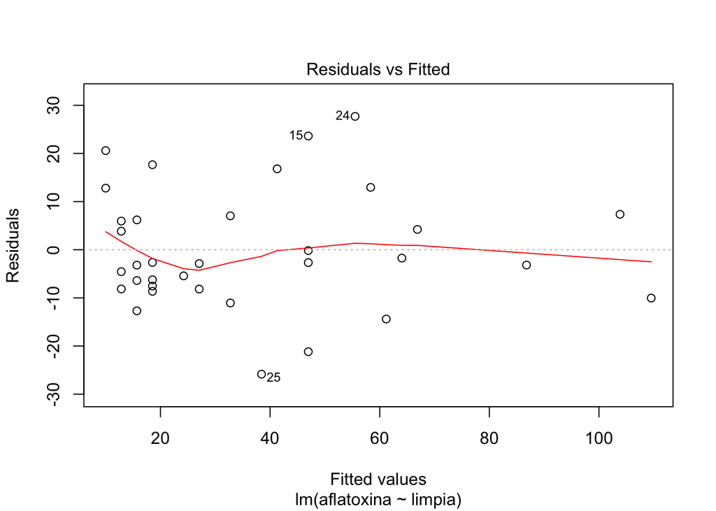

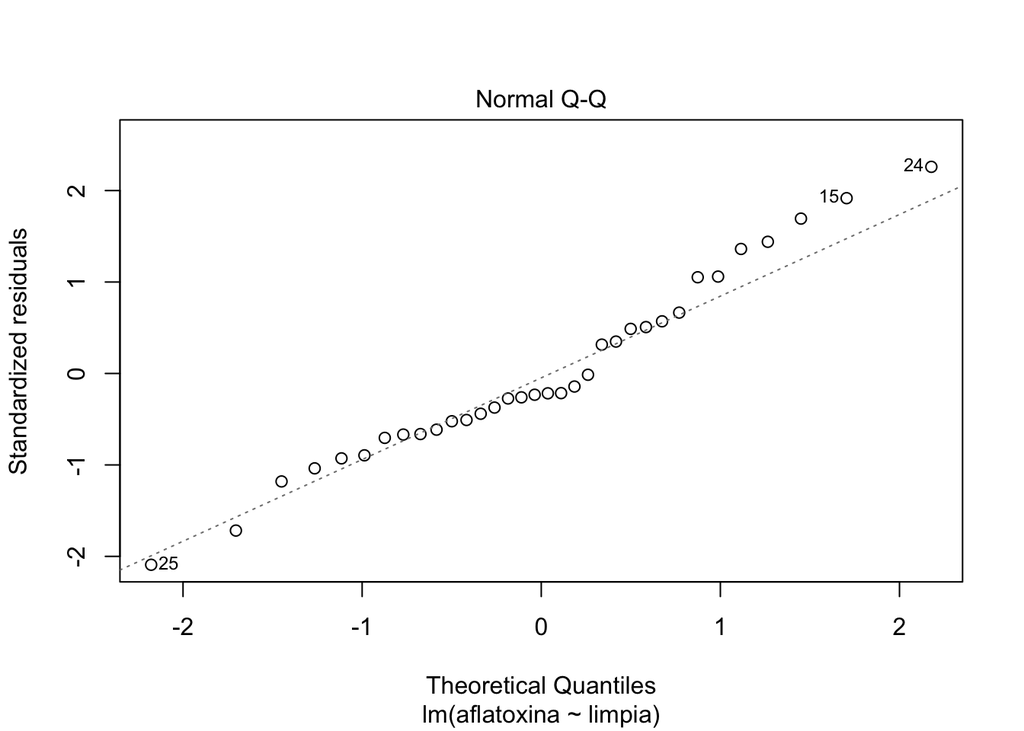

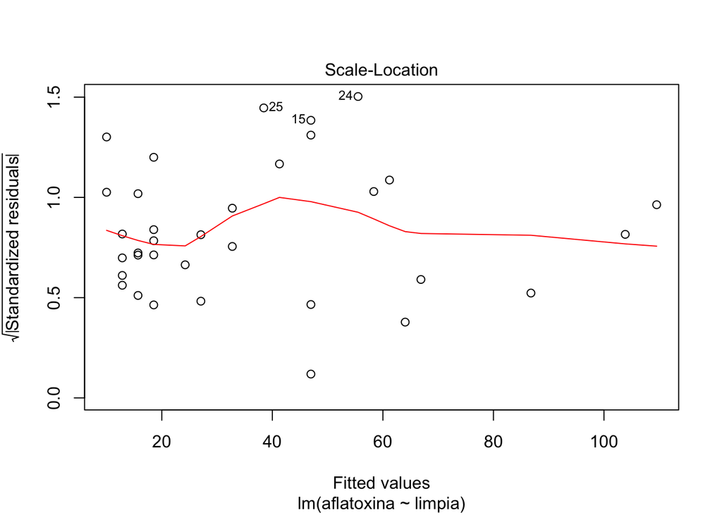

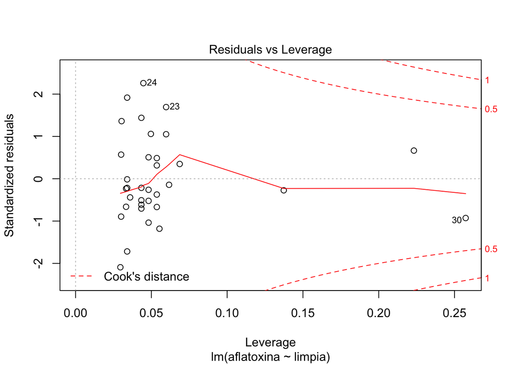

```r
## Revisión de los supuestos primarios mediante la opción de plot()
plot(regresion_lineal)
```

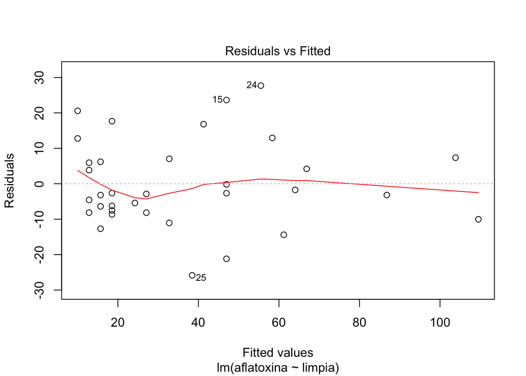

```r
## Si le interesaría controlar los gráficos se puede ejecutar lo siguiente:
par(mfrow=c(1,1))
plot(regresion_lineal, which=1)
```

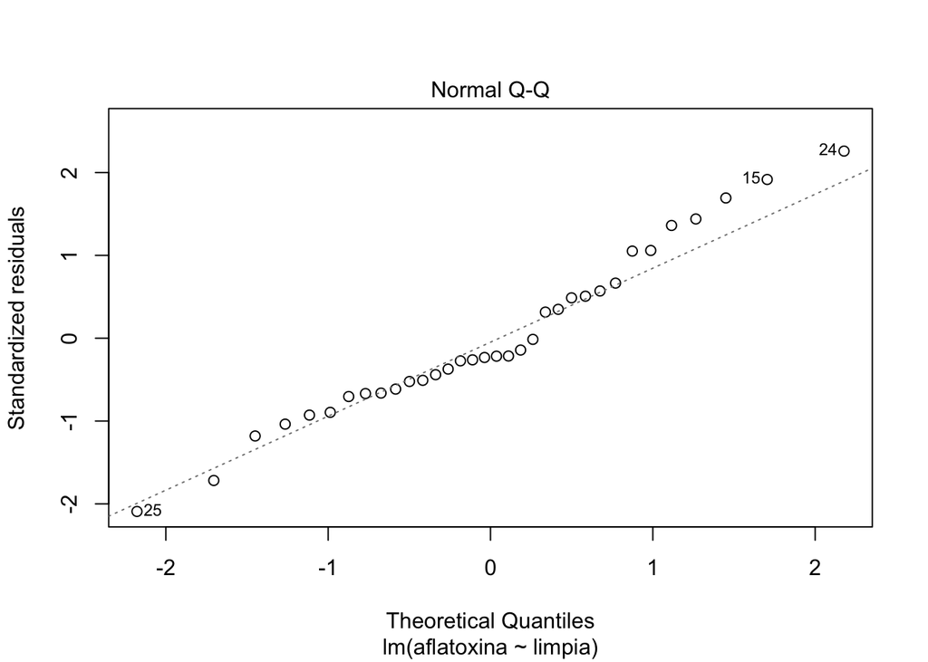

```r
plot(regresion_lineal, which=2)
```

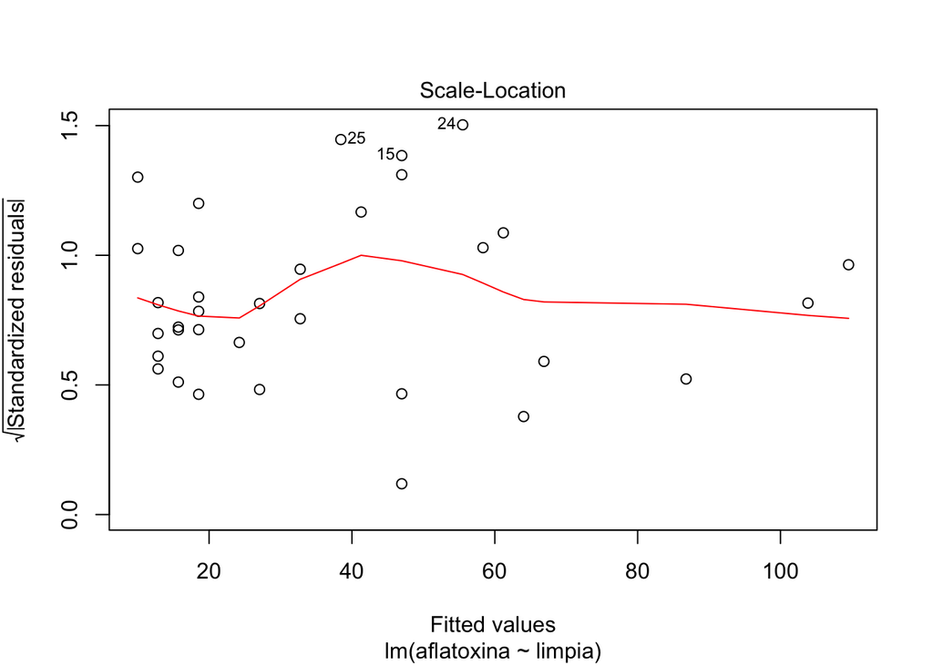

```r
plot(regresion_lineal, which=3)
```

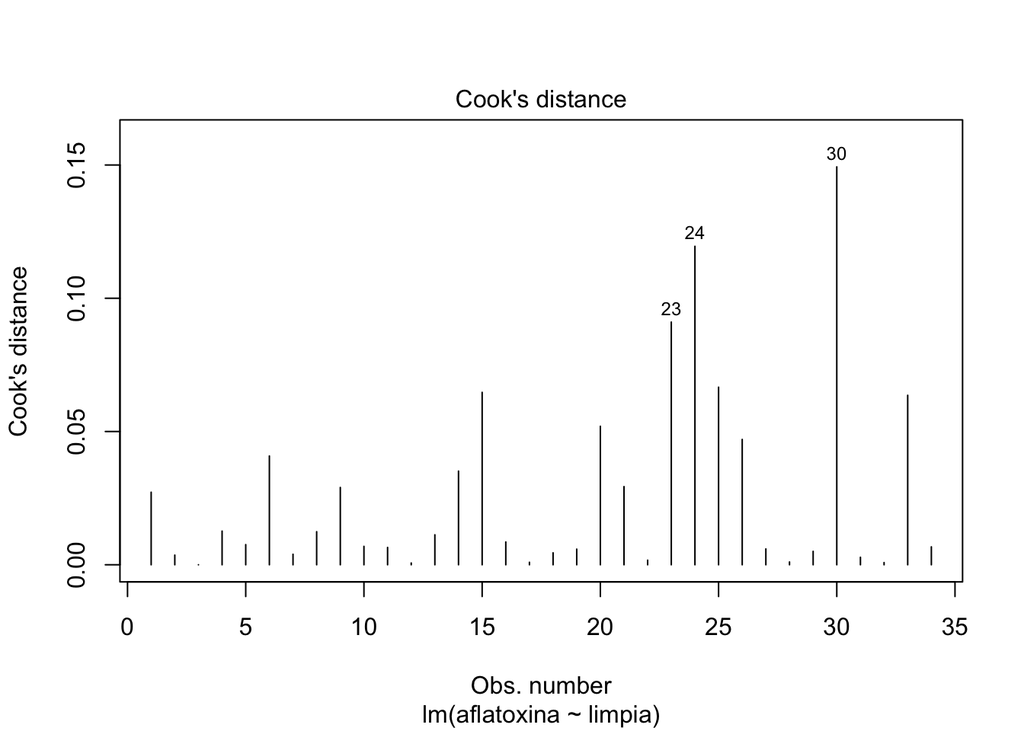

```r
plot(regresion_lineal, which=4)
```

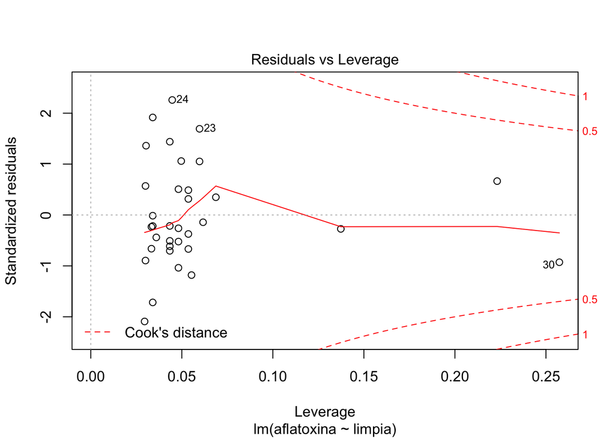

```r
plot(regresion_lineal, which=5)
```

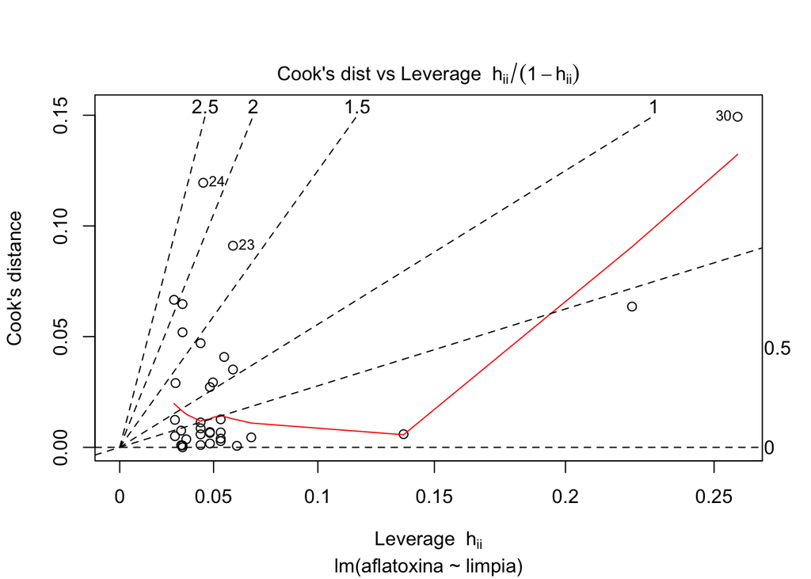

```r
plot(regresion_lineal, which=6)
```